# Happiness report

Yuheng Peng

12/18/2019

### Background Information

The report examine the state of happiness in today’s world to demonstrate how personal and national differences in happiness are understood by the new science of happiness.

### Research Question

1.where is the most happinest countries? 2. what factors impact the happiness score. 3.Which country have greatest improve in ranking and which attribute impove the most?

```r
rm(list = ls())
library(DataComputing)
library(tidyverse)
library(devtools)
library(mosaic)
```

### Data Importing

```r
x2018<-read.csv("D:/HW/Stat184/2018.csv")
x2019<-read.csv("D:/HW/Stat184/2019.csv")
```

### Data components

```r
head(x2018);
```

|  | Overall.rank | Country.or.region | Score | GDP.per.capita | Social.support | Healthy.life.expectancy | Freedom.to.make.life.choices | Generosity | Perceptions.of.corruption |
| --- | --- | --- | --- | --- | --- | --- | --- | --- | --- |
| 1 | 1 | Finland | 7.632 | 1.305 | 1.592 | 0.874 | 0.681 | 0.202 | 0.393 |
| 2 | 2 | Norway | 7.594 | 1.456 | 1.582 | 0.861 | 0.686 | 0.286 | 0.340 |
| 3 | 3 | Denmark | 7.555 | 1.351 | 1.590 | 0.868 | 0.683 | 0.284 | 0.408 |
| 4 | 4 | Iceland | 7.495 | 1.343 | 1.644 | 0.914 | 0.677 | 0.353 | 0.138 |
| 5 | 5 | Switzerland | 7.487 | 1.420 | 1.549 | 0.927 | 0.660 | 0.256 | 0.357 |
| 6 | 6 | Netherlands | 7.441 | 1.361 | 1.488 | 0.878 | 0.638 | 0.333 | 0.295 |

```r
head(x2019)
```

|  | Overall.rank | Country.or.region | Score | GDP.per.capita | Social.support | Healthy.life.expectancy | Freedom.to.make.life.choices | Generosity | Perceptions.of.corruption |
| --- | --- | --- | --- | --- | --- | --- | --- | --- | --- |
| 1 | 1 | Finland | 7.769 | 1.340 | 1.587 | 0.986 | 0.596 | 0.153 | 0.393 |
| 2 | 2 | Denmark | 7.600 | 1.383 | 1.573 | 0.996 | 0.592 | 0.252 | 0.410 |
| 3 | 3 | Norway | 7.554 | 1.488 | 1.582 | 1.028 | 0.603 | 0.271 | 0.341 |
| 4 | 4 | Iceland | 7.494 | 1.380 | 1.624 | 1.026 | 0.591 | 0.354 | 0.118 |
| 5 | 5 | Netherlands | 7.488 | 1.396 | 1.522 | 0.999 | 0.557 | 0.322 | 0.298 |
| 6 | 6 | Switzerland | 7.480 | 1.452 | 1.526 | 1.052 | 0.572 | 0.263 | 0.343 |

### Q1

From table 2019,the top 15 most happy countries, 10 countries from Europe, 2 countries from oceania, 1 country from Asia,1 country from North America and 1 country from Central America. From Scecond table 2018, the top 15 most happy countries, 11 countries from Europe, 2 countries from oceania,1 country from North America and 1 country from Central America.

```r
x2018%>%
  select(Country.or.region,Score)%>%
  arrange(desc(Score))%>%
  head(15)
```

|  | Country.or.region | Score |
| --- | --- | --- |
| 1 | Finland | 7.632 |
| 2 | Norway | 7.594 |
| 3 | Denmark | 7.555 |
| 4 | Iceland | 7.495 |
| 5 | Switzerland | 7.487 |
| 6 | Netherlands | 7.441 |
| 7 | Canada | 7.328 |
| 8 | New Zealand | 7.324 |
| 9 | Sweden | 7.314 |
| 10 | Australia | 7.272 |

[output cut: 5 more lines]

```r
x2019%>%
  select(Country.or.region,Score)%>%
  arrange(desc(Score))%>%
  head(15)
```

|  | Country.or.region | Score |
| --- | --- | --- |
| 1 | Finland | 7.769 |
| 2 | Denmark | 7.600 |
| 3 | Norway | 7.554 |
| 4 | Iceland | 7.494 |
| 5 | Netherlands | 7.488 |
| 6 | Switzerland | 7.480 |
| 7 | Sweden | 7.343 |
| 8 | New Zealand | 7.307 |
| 9 | Canada | 7.278 |
| 10 | Austria | 7.246 |

[output cut: 5 more lines]

From the world map we can see that North America have high happiniess score and Africa have low happniess score.

```
Mapping API still under development and may change in future releases.
4 items were not translated
```

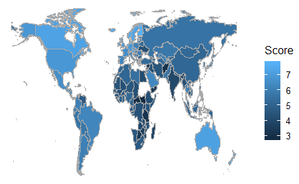

```r
x2019%>%
WorldMap(key="Country.or.region", fill=Score)
```

## Q2

### Generosity

It shows that Generosity is not a strong factor for overall happiness ranking.

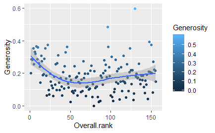

```r
ggplot(data=x2018,aes(x=Overall.rank,y=Generosity))+
  geom_point()+
  aes(colour=Generosity) +
  geom_smooth(method=loess)
```

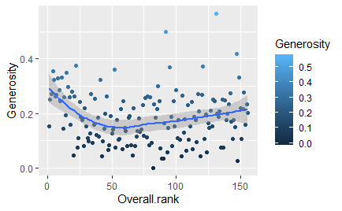

```r
ggplot(data=x2019,aes(x=Overall.rank,y=Generosity))+
  geom_point()+
  aes(colour=Generosity) +
  geom_smooth(method=loess)
```

### GDP per Capital

It shows that GDP is a strong factor for overall happiness ranking.

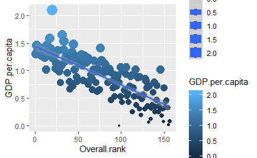

```r
ggplot(data=x2018,aes(x=Overall.rank,y=GDP.per.capita))+
  geom_point()+
  aes(colour=GDP.per.capita)+
  aes(size=GDP.per.capita)+
  geom_smooth(method=lm)
```

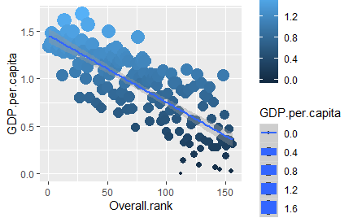

```r
ggplot(data=x2019,aes(x=Overall.rank,y=GDP.per.capita))+
  geom_point()+
  aes(colour=GDP.per.capita)+
  aes(size=GDP.per.capita)+
  geom_smooth(method=lm)
```

### social support

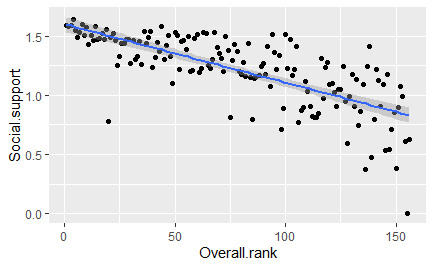

```r
ggplot(data=x2018,aes(x=Overall.rank,y=Social.support))+
  geom_point() +
  geom_smooth(method=lm)
```

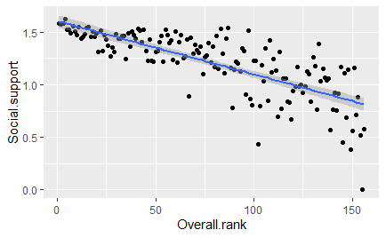

```r
ggplot(data=x2019,aes(x=Overall.rank,y=Social.support))+
  geom_point() +
  geom_smooth(method=lm)
```

## Q3

According to the table, Benin improve the most over past year. Benin improve 34 levels.

```r
x2019%>%
  mutate(rank19=Overall.rank,Country=Country.or.region)%>%
  select(Country,rank19)%>%
  left_join(x2018%>%
          select(Country.or.region,Overall.rank),by=c("Country"="Country.or.region"))%>%
  mutate(improveRank=Overall.rank-rank19)%>%
  arrange(desc(improveRank))
```

```
Column `Country`/`Country.or.region` joining factors with different levels, coercing to character vector
```

| Country | rank19 | Overall.rank | improveRank |
| --- | --- | --- | --- |
| Benin | 102 | 136 | 34 |
| Guinea | 118 | 140 | 22 |
| Kosovo | 46 | 66 | 20 |
| Niger | 114 | 134 | 20 |
| Bosnia and Herzegovina | 78 | 93 | 15 |
| Tajikistan | 74 | 88 | 14 |
| Honduras | 59 | 72 | 13 |
| Armenia | 116 | 129 | 13 |
| Cyprus | 49 | 61 | 12 |
| Italy | 36 | 47 | 11 |

[output cut: 146 more lines]

```r
#mutate data
HP2019<- x2018%>%
  mutate(Country=Country.or.region,GDP1=GDP.per.capita,SS1=Social.support,HL1=Healthy.life.expectancy,FREE1=Freedom.to.make.life.choices,GE1=Generosity,POF1=Perceptions.of.corruption)%>%
  filter(Country=="Benin")%>%
  select(Country,GDP1,SS1,HL1,FREE1,GE1,POF1)

HP2018<- x2019%>%
  mutate(Country=Country.or.region,GDP2=GDP.per.capita,SS2=Social.support,HL2=Healthy.life.expectancy,FREE2=Freedom.to.make.life.choices,GE2=Generosity,POF2=Perceptions.of.corruption)%>%
    filter(Country.or.region=="Benin")%>%
  select(Country,GDP2,SS2,HL2,FREE2,GE2,POF2)
```

### What is changed in Benin

According to the calculation, Benin’s 5 attributes GDP per capita, social support, Healthy life expectancy, Generosity and corruption increase easpecially the Healthy life expectancy， it grows 65% in 2018 and that makes Benin’s happiniess score higher and improve it’s rank from 136 to 102

```r
HP2019
```

| Country | GDP1 | SS1 | HL1 | FREE1 | GE1 | POF1 |
| --- | --- | --- | --- | --- | --- | --- |
| Benin | 0.378 | 0.372 | 0.24 | 0.44 | 0.163 | 0.067 |

```r
HP2018
```

| Country | GDP2 | SS2 | HL2 | FREE2 | GE2 | POF2 |
| --- | --- | --- | --- | --- | --- | --- |
| Benin | 0.393 | 0.437 | 0.397 | 0.349 | 0.175 | 0.082 |

```r
#define function
calculate=function(x,y){
  improve=(x-y)/y
  improve=improve*100
  return(improve)
}
```

```r
#calculate GDP
calculate(0.393,0.378)
```

```
[1] 3.968254
```

```r
#calculate Health
calculate(0.397,0.24)
```

```
[1] 65.41667
```

```r
#calculate Generosity
calculate(0.175,0.163)
```

```
[1] 7.361963
```

```r
#calculate corruption
calculate（0.082，0.067)
```

```
[1] 22.38806
```

```r
#calculate Free choice
calculate(0.349,0.44)
```

```
[1] -20.68182
```